# Analiza danych o trzech gatunkach irysów

**Iris setosa**

**Iris versicolor**

**Iris virginica**

[figure not shown]

- Zbiór danych zawiera informacje o trzech gatunkach irysów: **Iris setosa**, **Iris versicolor**, i **Iris virginica**.
- Dane obejmują pomiary czterech cech: długość i szerokość działki kielicha oraz długość i szerokość płatka.
- Każdy wiersz w zbiorze danych reprezentuje pojedynczy kwiat, a wartości pomiarów są podane w centymetrach.
- Zbiór składa się z 150 próbek, po 50 dla każdego gatunku.

### Zbadane cechy:

- **długość kielicha (sepal length)** - Długość kielicha w cm
- **szerokość kielicha (sepal width)** - Szerokość kielicha w cm
- **długość płatka (petal length)** - Długość płatka w cm
- **szerokość płatka (petal width)** - Szerokość płatka w cm
- **klasa (class)** - Klasa irysa (setosa, versicolor, virginica)

## Ogólny przegląd danych

Kilka przykładowych wierszy

|  | Długość kielicha | Szerokość kielicha | Długość płatka | Szerokość płatka | Gatunek |
| --- | --- | --- | --- | --- | --- |
| 149 | 5.9 | 3.0 | 5.1 | 1.8 | Iris-virginica |
| 122 | 7.7 | 2.8 | 6.7 | 2.0 | Iris-virginica |
| 148 | 6.2 | 3.4 | 5.4 | 2.3 | Iris-virginica |
| 135 | 7.7 | 3.0 | 6.1 | 2.3 | Iris-virginica |
| 0 | 5.1 | 3.5 | 1.4 | 0.2 | Iris-setosa |
| 112 | 6.8 | 3.0 | 5.5 | 2.1 | Iris-virginica |
| 119 | 6.0 | 2.2 | 5.0 | 1.5 | Iris-virginica |
| 142 | 5.8 | 2.7 | 5.1 | 1.9 | Iris-virginica |

Sprawdzamy czy są brakujące wartości w zestawie danych.

```
Długość kielicha      0
Szerokość kielicha    0
Długość płatka        0
Szerokość płatka      0
Gatunek               0
dtype: int64
```

- Dane zawierają 150 wpisów, w każdej kolumnie jest 150 wartości
- Nie brakuje danych w żadnym rekordzie.

## Korekta danych

W celu dokładniejszej analizy dodane zostały kolumny danych ze współczynnikami kształtów kielicha i płatka (długość/szerokość).

**Statystyki wartości liczbowych**

|  | Długość kielicha | Szerokość kielicha | Długość płatka | Szerokość płatka | Kształt kielicha | Kształt płatka |
| --- | --- | --- | --- | --- | --- | --- |
| count | 150.000000 | 150.000000 | 150.000000 | 150.000000 | 150.000000 | 150.000000 |
| mean | 5.843333 | 3.054000 | 3.758667 | 1.198667 | 1.955144 | 4.367166 |
| std | 0.828066 | 0.433594 | 1.764420 | 0.763161 | 0.398697 | 2.651508 |
| min | 4.300000 | 2.000000 | 1.000000 | 0.100000 | 1.268293 | 2.125000 |
| 25% | 5.100000 | 2.800000 | 1.600000 | 0.300000 | 1.551915 | 2.802381 |
| 50% | 5.800000 | 3.000000 | 4.350000 | 1.300000 | 2.032292 | 3.300000 |
| 75% | 6.400000 | 3.300000 | 5.100000 | 1.800000 | 2.224910 | 4.666667 |
| max | 7.900000 | 4.400000 | 6.900000 | 2.500000 | 2.961538 | 15.000000 |

|  | Gatunek | Iris-setosa | Iris-versicolor | Iris-virginica |
| --- | --- | --- | --- | --- |
| Długość kielicha | min | 4.300000 | 4.900000 | 4.900000 |
|  | median | 5.000000 | 5.900000 | 6.500000 |
|  | max | 5.800000 | 7.000000 | 7.900000 |
| Szerokość kielicha | min | 2.300000 | 2.000000 | 2.200000 |
|  | median | 3.400000 | 2.800000 | 3.000000 |
|  | max | 4.400000 | 3.400000 | 3.800000 |
| Kształt kielicha | min | 1.268293 | 1.764706 | 1.823529 |
|  | median | 1.467708 | 2.161290 | 2.169540 |
|  | max | 1.956522 | 2.818182 | 2.961538 |
| Długość płatka | min | 1.000000 | 3.000000 | 4.500000 |
|  | median | 1.500000 | 4.350000 | 5.550000 |
|  | max | 1.900000 | 5.100000 | 6.900000 |
| Szerokość płatka | min | 0.100000 | 1.000000 | 1.400000 |
|  | median | 0.200000 | 1.300000 | 2.000000 |
|  | max | 0.600000 | 1.800000 | 2.500000 |
| Kształt płatka | min | 2.666667 | 2.666667 | 2.125000 |
|  | median | 7.000000 | 3.240385 | 2.666667 |
|  | max | 15.000000 | 4.100000 | 4.000000 |

- Przeliczenie dla wszystkich pomiarów współczynników kształtów (długość/szerokość) kielicha i płatka pomaga zauważyć, że dane należy rozpatrywać również oddzielnie dla każdego gatunku irysa.
- Podstawowe wartości statystyczne pozwalają na wstępne zauważenie różnic kształtów dla różnych gatunków irysów.
- Widzimy, że wymiary płatka, a szczególnie szerokość, bardziej różnią się pomiędzy gatunkami, niż wymiary kielicha.
- Wprowadzenie parametru kształt płatka/kielicha szczególnie uwypukla różnice pomiędzy Iris-setosa, a pozostałymi gatunkami.

## Analiza zmiennych i wartości odstających

Wykres **Długości Kielicha** wykazuje nieduże zróżnicowanie tego wymiaru. Na podstawie tylko tego pomiaru ciężko byłoby określić z którym gatunkiem mamy do czynienia.

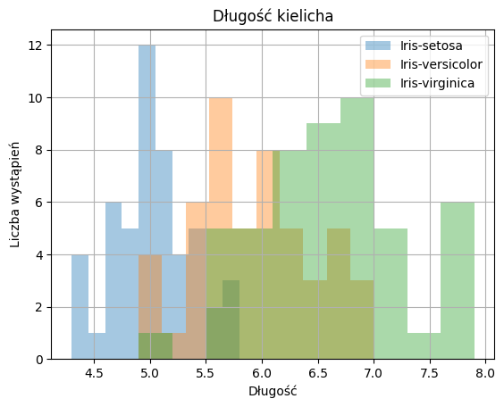

Na wykresie **Szerokości Kielicha** Widzimy pewne rozmieszczenie danych, jednak zachodzą one na siebie w dużym stopniu.

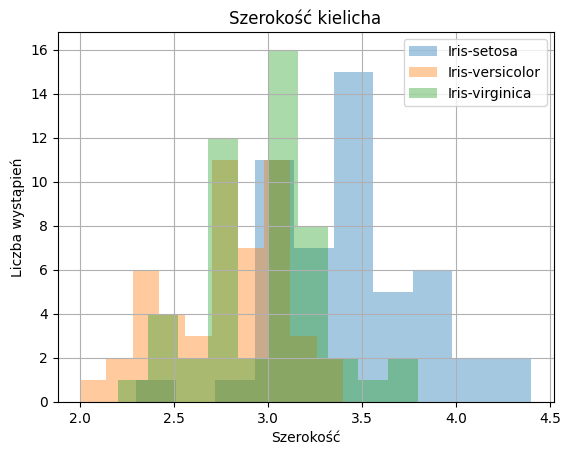

Wykres **Kształtu Kielicha** pozwala z dużą pewnością oddzielić gatunek Irys Setosa od pozostałych.

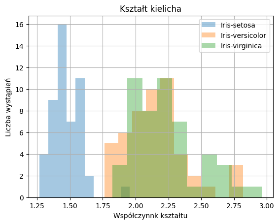

**Długość płatka** niemal od razu pozwala nam stwierdzić z którym gatunkiem mamy do czynienia.

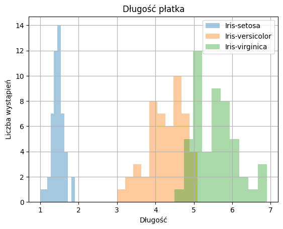

Zmierzona **Szerokość Płatka** również z dużym prawdopodobnieństwem umożliwia indentyfikację gatunku irysa.

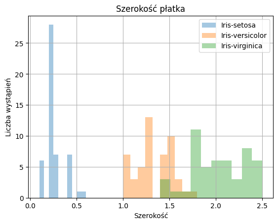

Parametr **Kształt Płatka** w tym przypadku jest mniej użyteczny, nie pomaga nam w zgadywaniu gatunku.

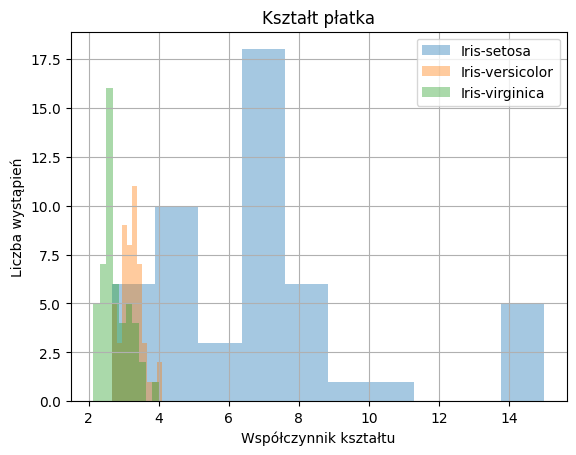

Wydaje się, że poszczególne kwiaty gatunku **Iris setosa** mają bardzo podobne płatki. Różnice ich wymiarów są znacząco mniejsze niż w przypadku innych gatunków. Widzimy tylko kilka wartości odstających.

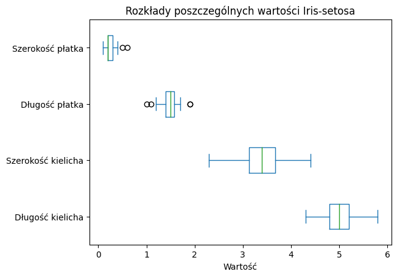

W gatunku **Iris Versicolor** płatki są trochę większe niż poprzedniego gatunku. Pomiary wydają się bardziej spójne - jest tylko jedna wartość odstająca w Długości płatka.

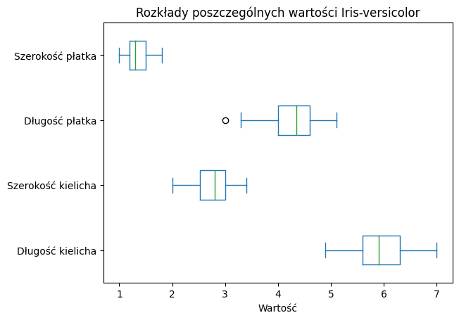

Gatunek **Iris Virginica** ma podobne wymiary do **Iris Versicolor**. Wartości odstających nie ma dużo również w tym przypadku.

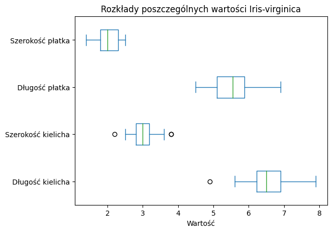

## Analiza relacji między zmiennymi

Z pomiarów **wymiarów kielicha** można z dużą pewnością odróżnić Iris Setosa od pozostałych gatunków.

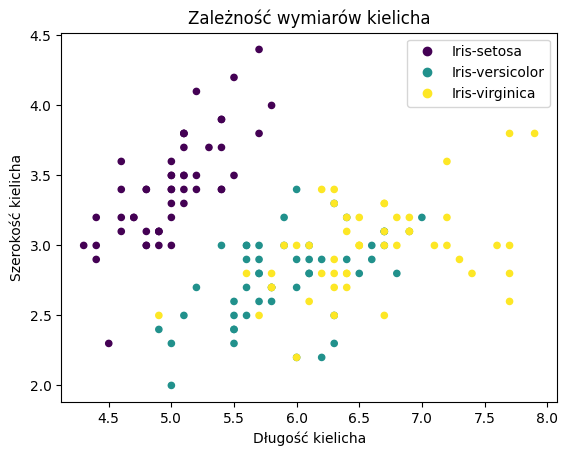

Pomiary **wymiarów płatków** już jednoznacznie nam określają który kwiat jest z gatunku Iris Setosa. A pozostałe gatunki można rozróżnić dużą pewnością, chociaż używając tylko tego wykresu możemy popełnić kilka pomyłek.

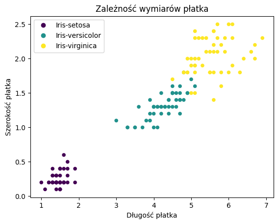

- Tabela korelacji **Iris Setosa** wskazuje nam na silną korelację pomiędzy długością i szerokością kielicha.
- Ta sama korelacja w przypadku płatka jest już dużo mniej wyraźna.
- Jeszcze mniejsza koleracja dotyczy wymiarów kielicha do płatka.

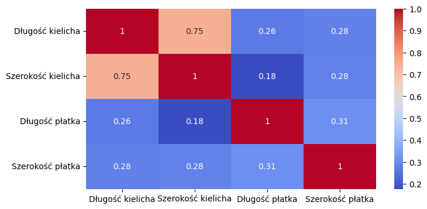

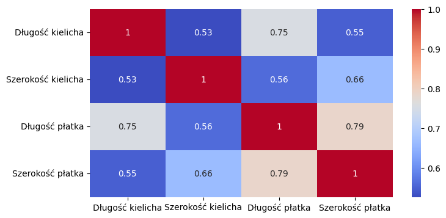

- W przypadku **Iris Virginica** najsilniej korelują długość kielicha i długość płatka - jest to najsilniejsza korelacja w całym zbiorze danych.
- Poza tym pozostałe wymiary są dużo słabiej powiązane między sobą. Najsłabiej oddziaływują na siebie długość kielicha i szerokość płatka.

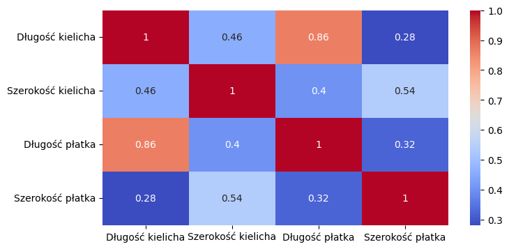